# Data Analysis of Covid-19

Akhil kusa, Hui Yee Tan, Vishweshwari Joshi, Vishnu Kalyan Mylavarapu

11/24/2020

```r
pkgs<-c('plyr','dplyr','ggplot2','tidyr','ggmap','devtools','mapdata')
install.packages(pkgs,repos = "http://cran.us.r-project.org")
```

## Introduction

The coronavirus disease has greatly impacted the lifestyle of human beings all over the globe in 2020. The outbreak started in Wuhan, China in December of 2019, and the virus is known as COVID-19. In March 2020, COVID-19 was declared as a pandemic by the World Health Organization (WHO). As researchers all around the world are racing to develop a vaccine for COVID-19, there are some studies that intrigued us. Researchers of Hydroxychloroquine, which is a drug used to treat malaria, have expressed previous parasitic viral infections (mainly malaria) can reduce the symptoms of COVID-19. A similar research also shows a correlation between Chloroquine, which is a stronger drug used to treat parasitic viruses and other auto-immune diseases, and the SARS virus, which also belongs to the coronavirus family. Those previous studies have motivated us to explore several findings in the datasets of COVID-19 and malaria cases.

This study is divided into two parts. For the first part, we will break down the statistics of COVID-19 to evaluate how the factors contribute to the COVID-19 result of each country. The factors include government stringency, population, age, gdp, health conditions, health care facilities, citizen’s life expectancy, and human development index (hdi). The second part is to study whether the prevalence of malaria impacts COVID-19 results. These findings may be useful in terms of slowing the spread of COVID-19, and strategically prioritizing the distributions of COVID-19 vaccine.

## Raw Data

The main dataset we are using for this study contains the statistics of COVID-19 of all countries. The dataset can be found at https://ourworldindata.org/coronavirus-source-data, and we name it `covid`. Another dataset we use for the second part of this study contains the statistics of malaria in 2017, which can be found at https://www.kaggle.com/imdevskp/malaria-dataset?select=reported_numbers.csv. Here, we will only summarize the `covid` dataset.

Summary of `Covid` Dataset:

- Format: CSV(available in multiple formats)
- Link:https://ourworldindata.org/coronavirus-source-data
- Data access date:10th October 2020 (updates monthly)
- Columns: 43(2 empty)
- Rows:50000
- Contains several null values, needs a lot of cleaning

After cleaning the data we focussed on major continents like Africa, Asia,Europe and North America. The data after cleaning for these continents are as follows:

We further selected only the important attributes which were needed for our analysis.

## Data Cleaning

As this is a large dataset, we break them down into smaller datasets that only focus of one continent, which include Africa, Asia, Europe, and North America.

```r
library(dplyr)
covid<- read.csv("owid-covid-data.csv")
covid_Africa<-covid %>% filter(continent=="Africa")
covid_Europe<-covid %>% filter(continent=="Europe")
covid_Asia<-covid %>% filter(continent=="Asia")
covid_North_America<-covid %>% filter(continent=="North America")
```

For efficient data cleaning, we developed the following function to repeatedly remove missing data.

```r
delete.na <- function(DF, n=2) {
  DF[rowSums(is.na(DF)) <= n,]
}
```

The first step in data cleaning is to look for the numbers of missing value in each variables for all continents.

```r
#install.packages('devtools')
#install_github('tierneyn/visdat')
library(visdat)
library(devtools)
library(lubridate)
```

For Africa:

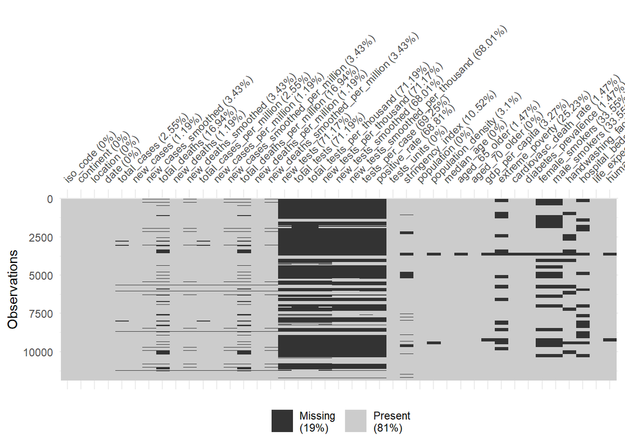

```r
vis_miss(covid_Africa,warn_large_data = FALSE)
```

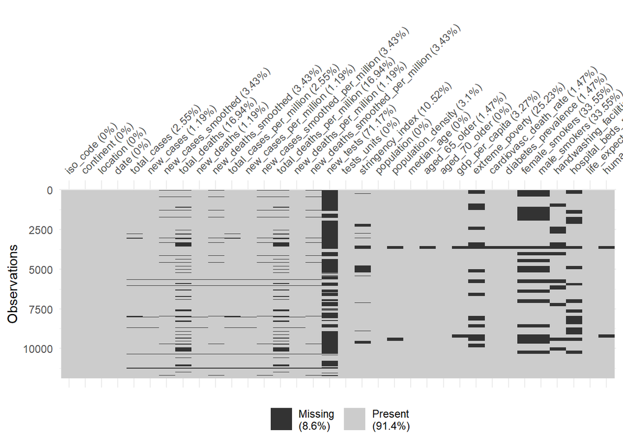

```r
#cleaning out the columns that have more than 50% missing values

covid_Africa$total_tests<-NULL
covid_Africa$total_tests_per_thousand<-NULL
covid_Africa$new_tests_per_thousand<-NULL
covid_Africa$new_tests_smoothed<-NULL
covid_Africa$new_tests_smoothed_per_thousand<-NULL
covid_Africa$tests_per_case<-NULL
covid_Africa$positive_rate<-NULL

vis_miss(covid_Africa)
```

```r
typeof(covid_Africa$female_smokers)
```

```
## [1] "double"
```

```r
mean(covid_Africa$female_smokers,na.rm = TRUE)
```

```
## [1] 2.52035
```

```r
covid_Africa %>% summarise(count=sum(is.na(female_smokers)))
```

```
##   count
## 1  3985
```

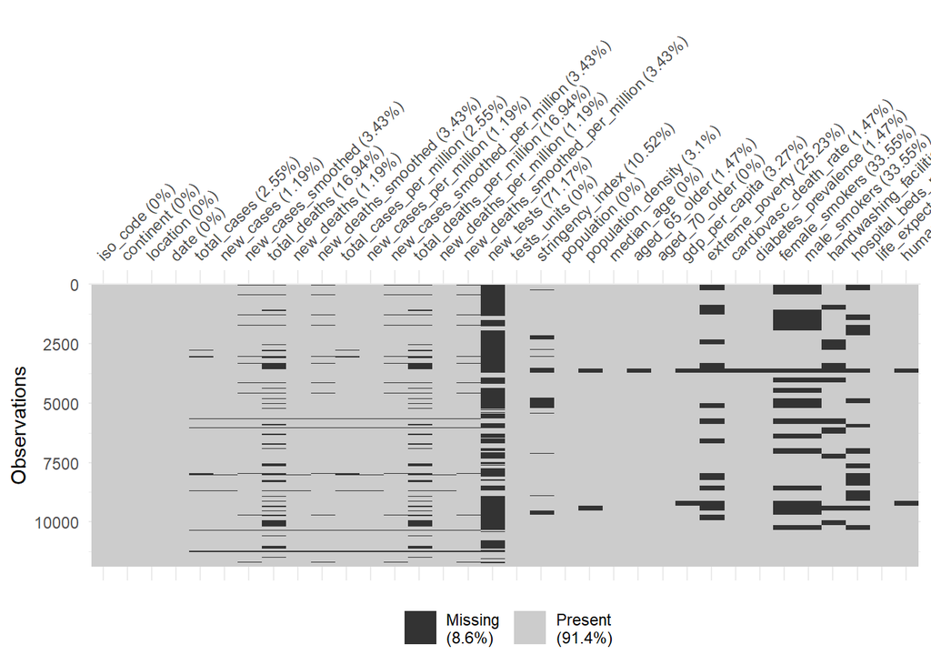

```r
vis_miss(covid_Africa,warn_large_data = FALSE)
```

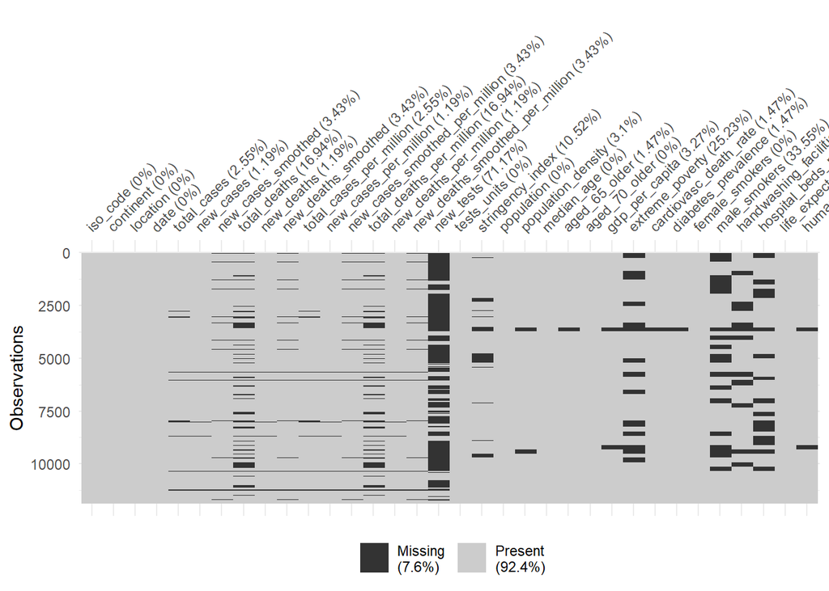

```r
covid_Africa$female_smokers<- ifelse(is.na(covid_Africa$female_smokers),2.5,covid_Africa$female_smokers)

vis_miss(covid_Africa,warn_large_data = FALSE)
```

```r
mean(covid_Africa$male_smokers,na.rm = TRUE)
```

```
## [1] 27.42549
```

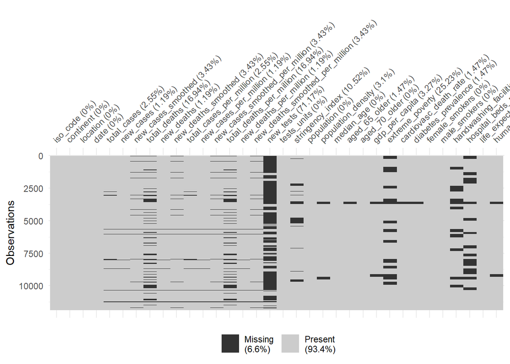

```r
covid_Africa$male_smokers<- ifelse(is.na(covid_Africa$male_smokers),27.42,covid_Africa$male_smokers)
vis_miss(covid_Africa,warn_large_data = FALSE)
```

```r
mean(covid_Africa$stringency_index,na.rm = TRUE)
```

```
## [1] 61.04331
```

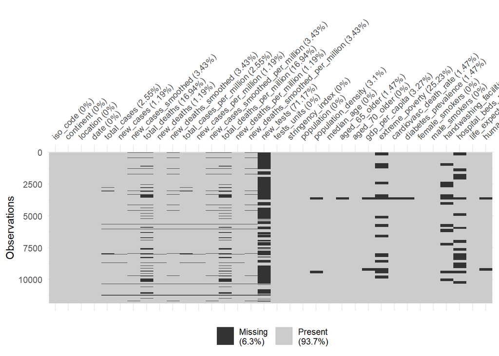

```r
covid_Africa$stringency_index<- ifelse(is.na(covid_Africa$stringency_index),61.04,covid_Africa$stringency_index)
vis_miss(covid_Africa,warn_large_data = FALSE)
```

```r
mean(covid_Africa$extreme_poverty,na.rm = TRUE)
```

```
## [1] 32.99789
```

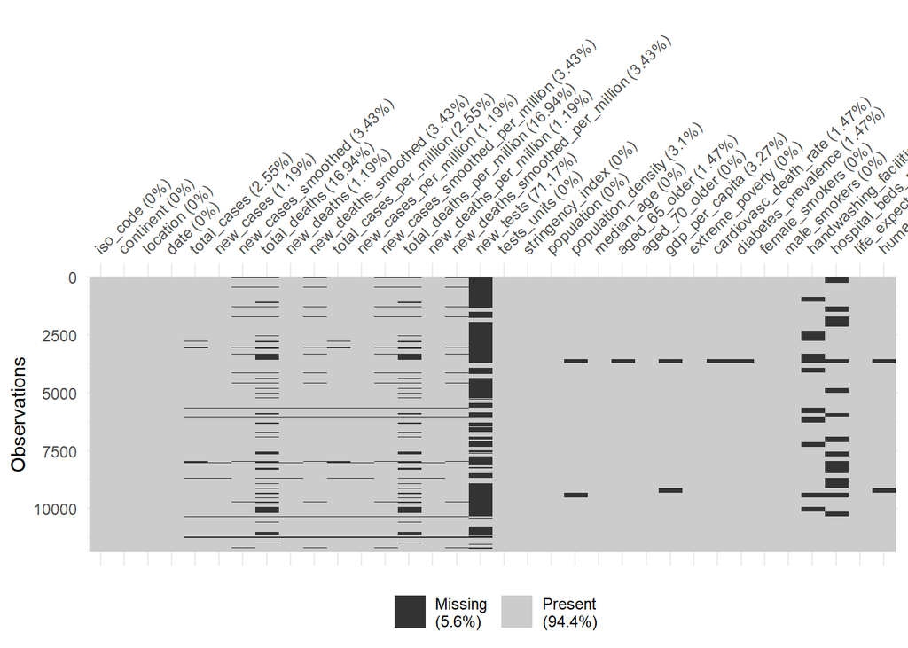

```r
covid_Africa$extreme_poverty<- ifelse(is.na(covid_Africa$extreme_poverty),32.997,covid_Africa$extreme_poverty)
vis_miss(covid_Africa,warn_large_data = FALSE)
```

```r
mean(covid_Africa$handwashing_facilities,na.rm = TRUE)
```

```
## [1] 26.56125
```

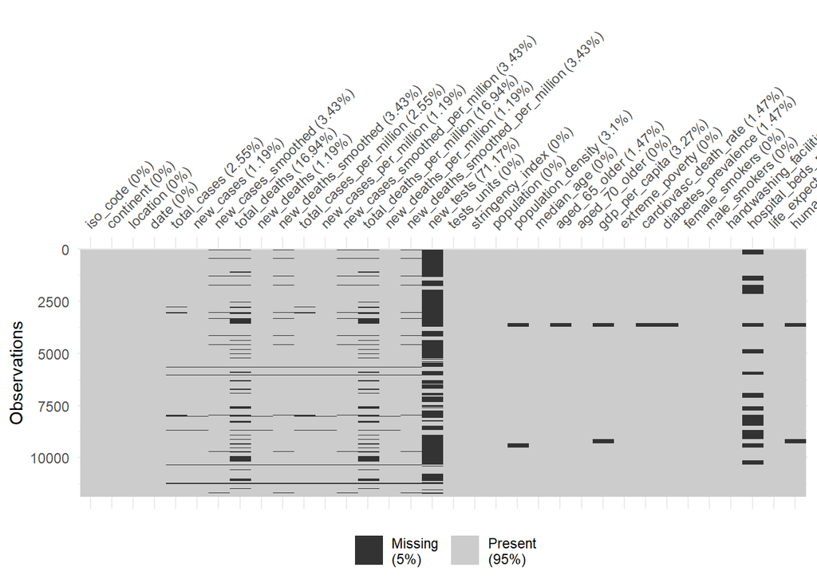

```r
covid_Africa$handwashing_facilities<- ifelse(is.na(covid_Africa$handwashing_facilities),26.56,covid_Africa$handwashing_facilities)
vis_miss(covid_Africa,warn_large_data = FALSE)
```

```r
mean(covid_Africa$hospital_beds_per_thousand,na.rm = TRUE)
```

```
## [1] 1.511614
```

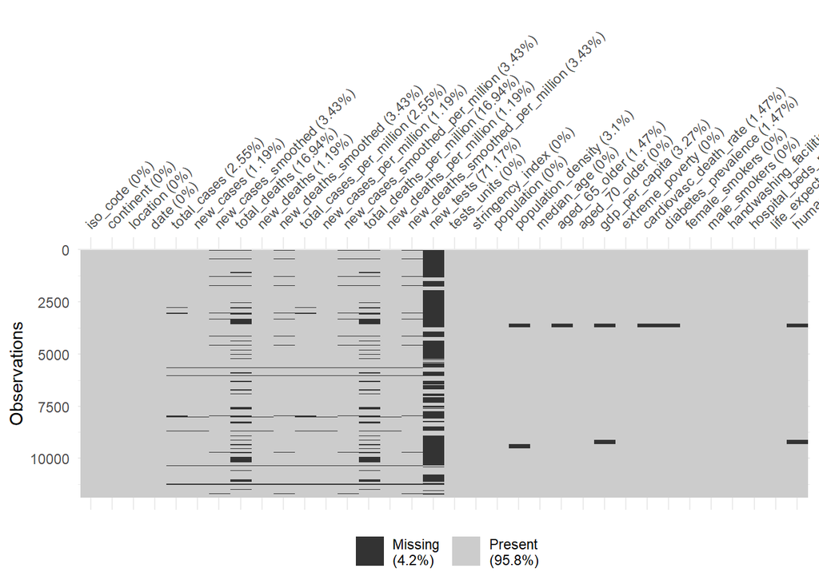

```r
covid_Africa$hospital_beds_per_thousand<- ifelse(is.na(covid_Africa$hospital_beds_per_thousand),1.511,covid_Africa$hospital_beds_per_thousand)
vis_miss(covid_Africa,warn_large_data = FALSE)
```

```r
mean(covid_Africa$human_development_index,na.rm = TRUE)
```

```
## [1] 0.5483778
```

```r
covid_Africa$human_development_index<- ifelse(is.na(covid_Africa$human_development_index),0.54,covid_Africa$human_development_index)


#column type reorganization

library(ggplot2)
covid_Africa$date<- mdy(covid_Africa$date)
max(covid_Africa$date)
```

```
## [1] "2020-10-16"
```

```r
min(covid_Africa$date)
```

```
## [1] "2019-12-31"
```

The data cleaning process of other continents are similar to Africa. The codes and outputs are included in the R markdown file, but will not be shown in the knitted document.

## Data Analysis

There are two parts in this data analysis. The first part is to analyze the `covid` dataset, and explore any findings that may be useful in terms of stopping the spread of COVID-19. The questions we have for this dataset are as followed:

1. Which country is worst affected?
2. What is the impact of Government stringency on spread of COVID-19?
3. Does population density have an impact on COVID-19?
4. What is the impact of smoking on COVID-19?
5. What is the impact of diabetes on COVID-19?
6. Which state should first get the vaccine to minimize deaths?

For the second part, we will investigate the relationship between prevalence of malaria and COVID-19.

### Part 1

#### Q1. Which countris worst affected?

First, let us look at the top countries that have the most cases in each continent.

```r
covid_asia_filter <- covid_Asia %>% group_by(location) %>% summarise(count=sum(new_cases,na.rm = TRUE))
```

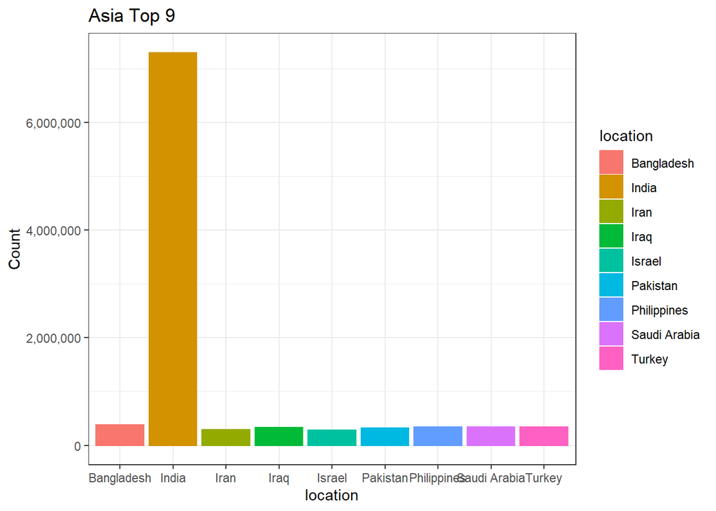

```r
covid_asia_filter<- head(covid_asia_filter[order(-covid_asia_filter$count),],9)
ggplot(covid_asia_filter,aes(x=location,y=count,color=location,fill=location))+geom_col()+ scale_y_continuous(name='Count',labels= scales::comma)+theme_bw()+ggtitle("Asia Top 9")
```

```r
covid_Africa_filter<-covid_Africa %>% group_by(location) %>% summarise(count=sum(new_cases,na.rm = TRUE))
```

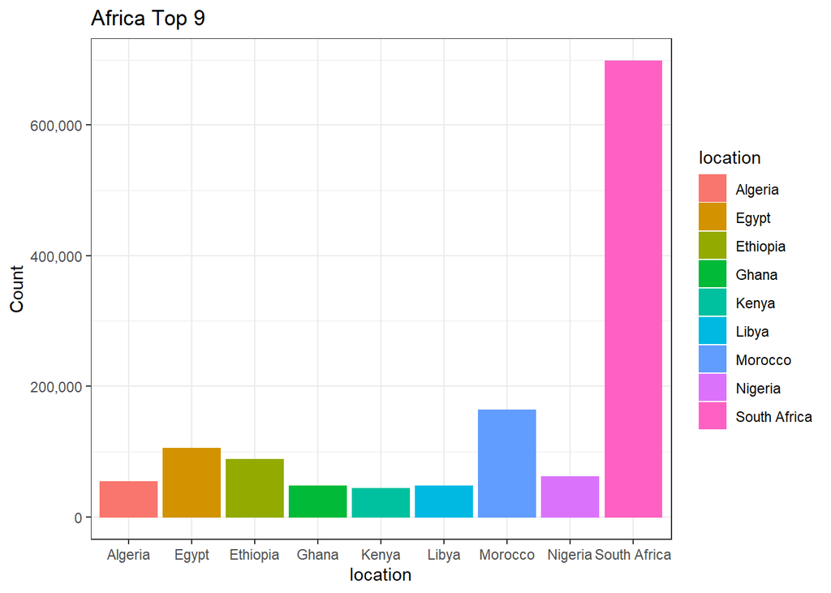

```r
covid_Africa_filter<- head(covid_Africa_filter[order(-covid_Africa_filter$count),],9)
ggplot(covid_Africa_filter,aes(x=location,y=count,color=location,fill=location))+geom_col()+scale_y_continuous(name='Count',labels= scales::comma)+theme_bw()+ggtitle("Africa Top 9")
```

```r
covid_Europe_filter<-covid_Europe %>% group_by(location) %>% summarise(count=sum(new_cases,na.rm = TRUE))
```

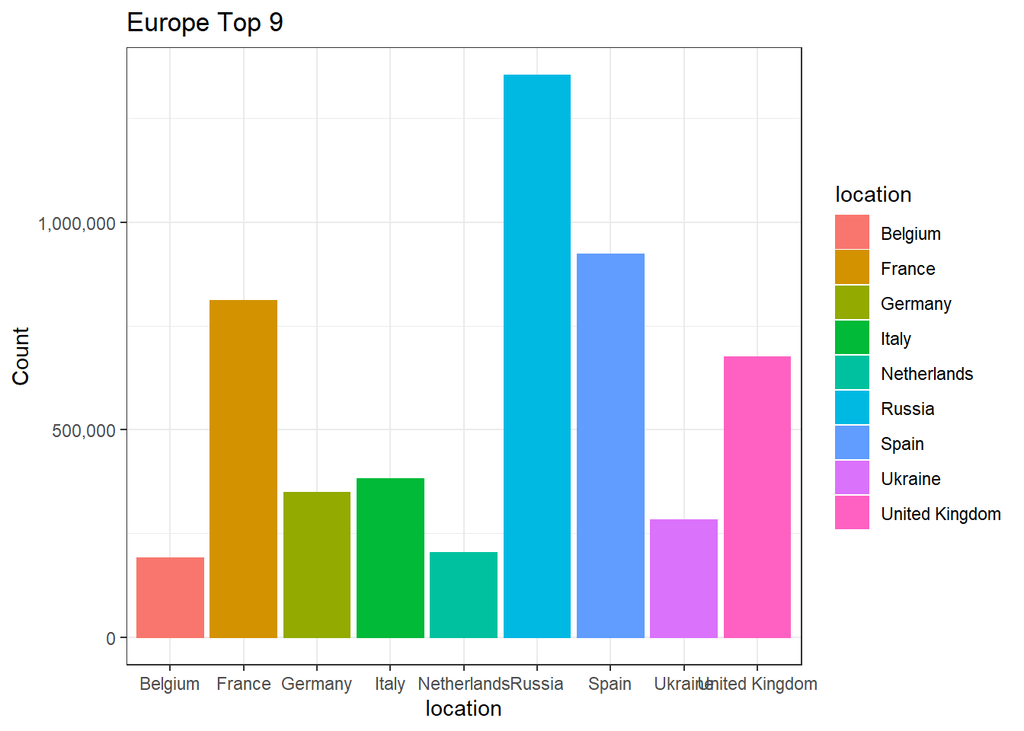

```r
covid_Europe_filter<- head(covid_Europe_filter[order(-covid_Europe_filter$count),],9)
ggplot(covid_Europe_filter,aes(x=location,y=count,color=location,fill=location))+geom_col()+scale_y_continuous(name='Count',labels= scales::comma)+theme_bw()+ggtitle("Europe Top 9")
```

```r
covid_North_America_filter<-covid_North_America %>% group_by(location) %>% summarise(count=sum(new_cases,na.rm = TRUE))
```

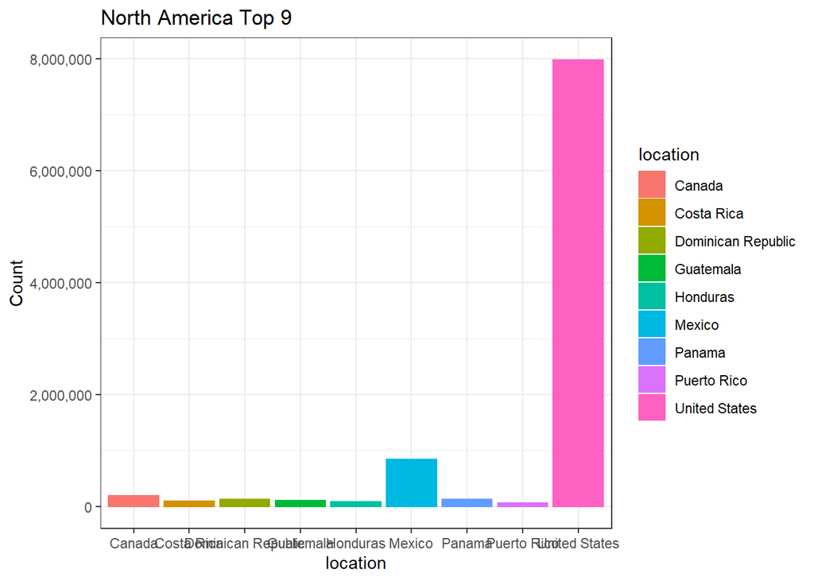

```r
covid_North_America_filter<- head(covid_North_America_filter[order(-covid_North_America_filter$count),],9)
ggplot(covid_North_America_filter,aes(x=location,y=count,color=location,fill=location))+geom_col()+scale_y_continuous(name='Count',labels= scales::comma)+theme_bw()+ggtitle("North America Top 9")
```

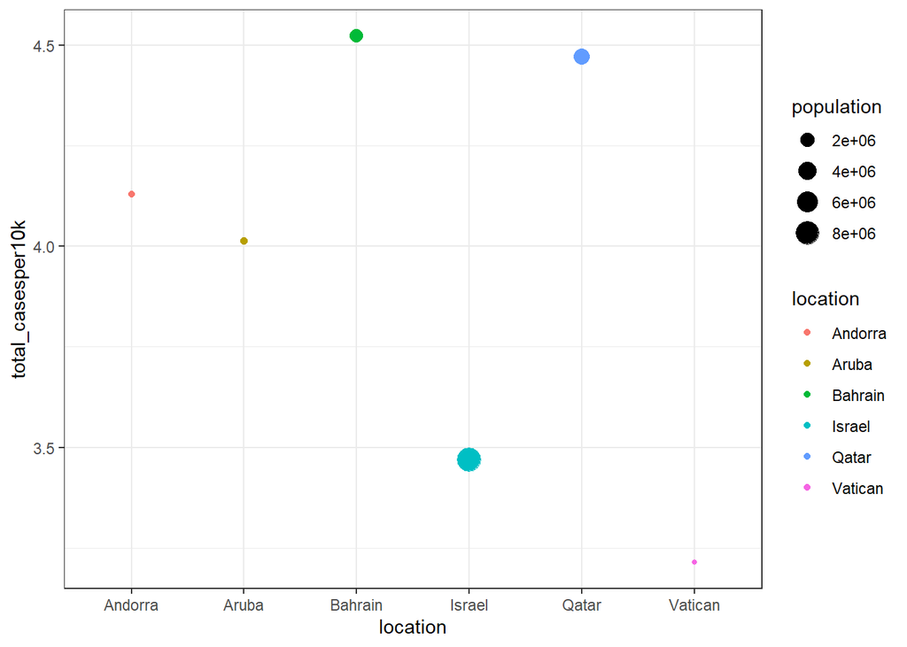

```r
covid$date<-mdy(covid$date)
data4<-covid %>% filter(date=='2020-10-16') %>% summarise(location,total_cases,population)
data4$total_casesper10k <- (data4$total_cases/data4$population)*100

data4<-data4[order(-data4$total_casesper10k),]

data5<-head(data4)

ggplot(data5,aes(location,total_casesper10k,color=location,size=population))+geom_point()+theme_bw()
```

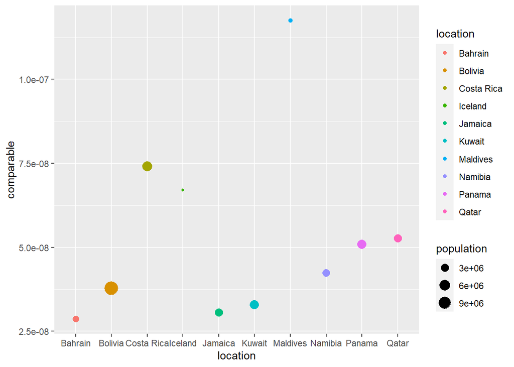

```r
compare2<-covid%>%filter(date=='2020-10-13')
compare2$comparable <- (compare2$total_cases/(compare2$population*compare2$total_tests))
compare2<-compare2[order(-compare2$comparable),]
compare3<-head(compare2,10)
ggplot(compare3,aes(x=location,y=comparable,color=location,size=population))+geom_point()
```

#### Q2. What is the impact of Government stringency on spread of COVID-19?

The correlation between government stringency and death rate is shown in the graph below:

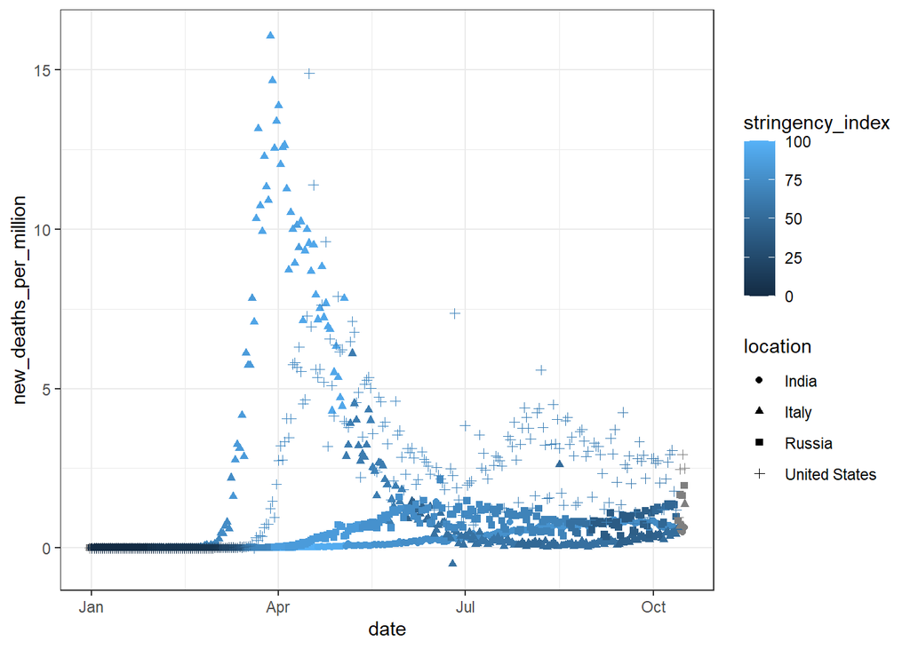

```r
strigency<-covid %>% filter(location=='India'|location=='United States'|location=='Russia'|location=='Italy')
strigency %>% ggplot(aes(x=date,y=new_deaths_per_million,shape=location,color=stringency_index))+
  geom_point()+theme_bw()
```

The higher the stringency index, the stricter the policies a country have on COVID-19. In other words, the country with 100 stringency index is the strictest. Looking at the graph above, countries with higher death rate have higher stringency index to control the spread of the virus.

#### Q3. Does population density have an impact on COVID-19?

The graph below shows the correlation between population density and new cases:

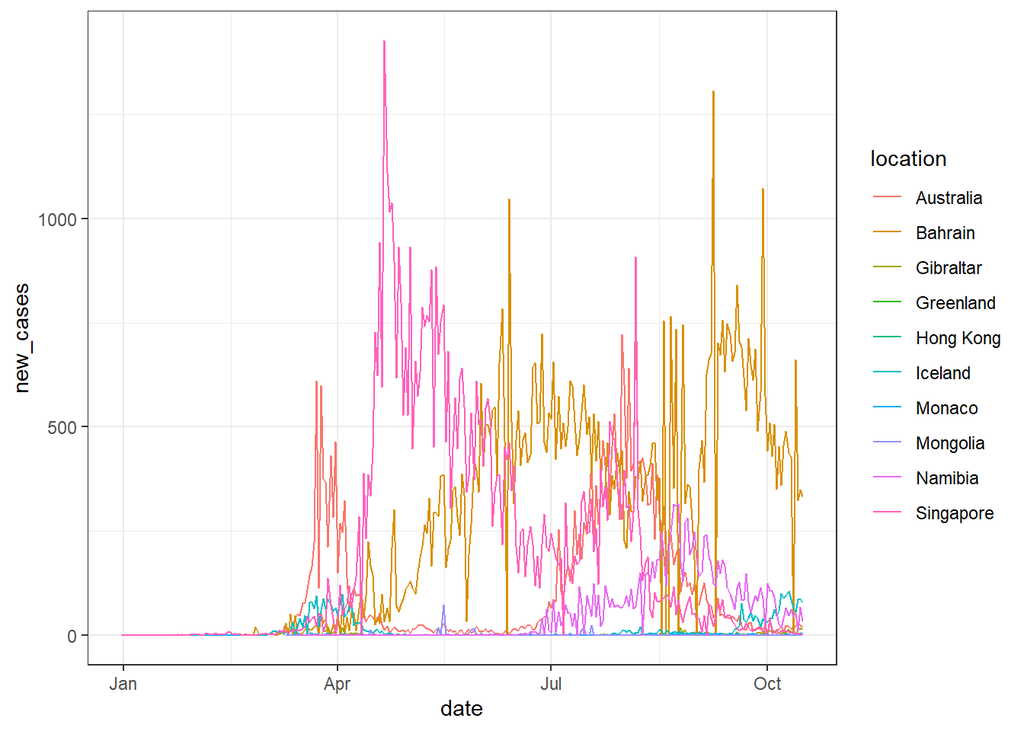

```r
dens<-covid[order(-covid$population_density),]
dens<-covid[order(covid$population_density),]

dens %>% filter(location == "Monaco"|location=="Singapore"|location=="Hong Kong"|location=="Gibraltar"|location=="Bahrain"|location == "Greenland"|location=="Mongolia"|location=="Namibia"|location=="Australia"|location=="Iceland") %>%  ggplot(aes(x = date, y = new_cases,color=location)) + geom_line()+theme_bw()
```